# 3a. Imputacja hot-deck

# 1 Wczytanie potrzebnych pakietów

**R**

```r
library(simputation)
library(VIM)
```

**Python**

```python
import numpy as np
import pandas as pd
import matplotlib.pyplot as plt
```

# 2 Przykład 1 z zajęć

Brakującą wartość zastępujemy wartością obserwowaną u innej jednostki z tego samego zbioru (dawcy). Omawiamy trzy warianty:

- losowy hot-deck – dawca losowany spośród wszystkich respondentów,
- losowy hot-deck w klasach imputacyjnych – dawca losowany z tej samej klasy,
- sekwencyjny hot-deck – dawcą jest poprzedni respondent po posortowaniu danych.

**R**

```r
przyklad1 <- data.frame(plec = c("K", "K", "K", "K", "M", "M", "M", "M"),
                        X = c(21, 24, 30, 35, 22, 28, 33, 40),
                        Y = c(25, NA, 35, NA, 45, NA, 55, 65))
przyklad1
```

```
  plec  X  Y
1    K 21 25
2    K 24 NA
3    K 30 35
4    K 35 NA
5    M 22 45
6    M 28 NA
7    M 33 55
8    M 40 65
```

Losowy hot-deck

```r
set.seed(2025)
przyklad1 |>
  impute_rhd(Y ~ 1)
```

```
  plec  X  Y
1    K 21 25
2    K 24 65
3    K 30 35
4    K 35 55
5    M 22 45
6    M 28 55
7    M 33 55
8    M 40 65
```

Losowy hot-deck w klasach imputacyjnych (klasy wyznacza `plec`)

```r
set.seed(2025)
przyklad1 |>
  impute_rhd(Y ~ plec)
```

```
  plec  X  Y
1    K 21 25
2    K 24 25
3    K 30 35
4    K 35 35
5    M 22 45
6    M 28 65
7    M 33 55
8    M 40 65
```

Step-by-step (w klasach)

```r
set.seed(2025)
przyklad1_wynik <- przyklad1
for (klasa in unique(przyklad1$plec)) {
  ## biorcy i dawcy z danej klasy
  biorcy <- which(przyklad1$plec == klasa & is.na(przyklad1$Y))
  dawcy <- which(przyklad1$plec == klasa & !is.na(przyklad1$Y))
  ## losujemy dawców ze zwracaniem i przepisujemy ich wartości
  wybrani <- dawcy[sample.int(length(dawcy), length(biorcy), replace = TRUE)]
  przyklad1_wynik$Y[biorcy] <- przyklad1$Y[wybrani]
}
przyklad1_wynik
```

```
  plec  X  Y
1    K 21 25
2    K 24 25
3    K 30 35
4    K 35 35
5    M 22 45
6    M 28 55
7    M 33 55
8    M 40 65
```

Sekwencyjny hot-deck: sortujemy po `X`, a brak uzupełniamy wartością poprzedniego respondenta.

```r
przyklad1 |>
  impute_shd(Y ~ X)
```

```
  plec  X  Y
1    K 21 25
2    K 24 45
3    K 30 35
4    K 35 55
5    M 22 45
6    M 28 45
7    M 33 55
8    M 40 65
```

To samo osobno w każdej klasie

```r
przyklad1 |>
  impute_shd(Y ~ X | plec)
```

```
  plec  X  Y
1    K 21 25
2    K 24 25
3    K 30 35
4    K 35 35
5    M 22 45
6    M 28 45
7    M 33 55
8    M 40 65
```

To samo z pakietem `VIM`. Funkcja dodaje kolumnę `Y_imp`, która wskazuje wartości zaimputowane.

```r
VIM::hotdeck(przyklad1, variable = "Y", ord_var = "X", domain_var = "plec")
```

```
  plec  X  Y Y_imp
1    K 21 25 FALSE
2    K 24 25  TRUE
3    K 30 35 FALSE
4    K 35 35  TRUE
5    M 22 45 FALSE
6    M 28 45  TRUE
7    M 33 55 FALSE
8    M 40 65 FALSE
```

**Python**

W popularnych pakietach Pythona nie ma standardowej funkcji do hot-decku, ale łatwo ją napisać samodzielnie.

```python
przyklad1 = pd.DataFrame({
    'plec': ["K", "K", "K", "K", "M", "M", "M", "M"],
    'X': [21, 24, 30, 35, 22, 28, 33, 40],
    'Y': [25, np.nan, 35, np.nan, 45, np.nan, 55, 65]
})
przyklad1
```

```
  plec   X     Y
0    K  21  25.0
1    K  24   NaN
2    K  30  35.0
3    K  35   NaN
4    M  22  45.0
5    M  28   NaN
6    M  33  55.0
7    M  40  65.0
```

```python
def hotdeck_losowy(dane, y, klasy=None):
    wynik = dane[y].copy()
    # bez klas wszystkie jednostki tworzą jedną grupę
    grupy = [dane.index] if klasy is None else dane.groupby(klasy, observed=True).groups.values()
    for idx in grupy:
        y_grupa = dane.loc[idx, y]
        biorcy = y_grupa.index[y_grupa.isna()]
        dawcy = y_grupa.dropna().to_numpy()
        # jeżeli w klasie nie ma dawców, braki pozostają
        if len(biorcy) > 0 and len(dawcy) > 0:
            wynik.loc[biorcy] = np.random.choice(dawcy, size=len(biorcy), replace=True)
    return wynik

def hotdeck_sekwencyjny(dane, y, sortowanie, klasy=None):
    wynik = dane[y].copy()
    grupy = [dane.index] if klasy is None else dane.groupby(klasy, observed=True).groups.values()
    for idx in grupy:
        y_grupa = dane.loc[idx].sort_values(sortowanie)[y]
        if y_grupa.notna().any():
            # brak na początku uzupełniamy ostatnim respondentem, tak jak impute_shd w R
            wynik.loc[y_grupa.index] = y_grupa.ffill().fillna(y_grupa.dropna().iloc[-1])
    return wynik
```

Losowy hot-deck

```python
np.random.seed(2025)
przyklad1.assign(Y=hotdeck_losowy(przyklad1, 'Y'))
```

```
  plec   X     Y
0    K  21  25.0
1    K  24  45.0
2    K  30  35.0
3    K  35  65.0
4    M  22  45.0
5    M  28  25.0
6    M  33  55.0
7    M  40  65.0
```

Losowy hot-deck w klasach imputacyjnych (klasy wyznacza `plec`)

```python
np.random.seed(2025)
przyklad1.assign(Y=hotdeck_losowy(przyklad1, 'Y', klasy='plec'))
```

```
  plec   X     Y
0    K  21  25.0
1    K  24  25.0
2    K  30  35.0
3    K  35  25.0
4    M  22  45.0
5    M  28  65.0
6    M  33  55.0
7    M  40  65.0
```

Sekwencyjny hot-deck: sortujemy po `X`, a brak uzupełniamy wartością poprzedniego respondenta.

```python
przyklad1.assign(Y=hotdeck_sekwencyjny(przyklad1, 'Y', 'X'))
```

```
  plec   X     Y
0    K  21  25.0
1    K  24  45.0
2    K  30  35.0
3    K  35  55.0
4    M  22  45.0
5    M  28  45.0
6    M  33  55.0
7    M  40  65.0
```

To samo osobno w każdej klasie

```python
przyklad1.assign(Y=hotdeck_sekwencyjny(przyklad1, 'Y', 'X', klasy='plec'))
```

```
  plec   X     Y
0    K  21  25.0
1    K  24  25.0
2    K  30  35.0
3    K  35  35.0
4    M  22  45.0
5    M  28  45.0
6    M  33  55.0
7    M  40  65.0
```

Sekwencyjny hot-deck działa jak `fill()` / `na.locf()` / `ffill()` z notatnika o imputacji dedukcyjnej na podstawie danych tekstowych, ale różni się uzasadnieniem. W tamtym przykładzie sortowanie po `liczba_pokoi` wyznaczało brakującą wartość, więc była to dedukcja. Tutaj zakładamy jedynie, że sąsiednie jednostki są do siebie podobne, więc wartość zaimputowana może się różnić od prawdziwej.

# 3 Przykład 2 – czytelnictwo

Porównujemy warianty hot-decku ze znaną prawdziwą wartością.

**R**

```r
## reading
data <- read.csv(file = "../../data/data4-czytelnictwo.csv",
                 colClasses = c("factor", "numeric", "factor", "logical", "logical"))
data$wiek_kat <- cut(data$wiek, breaks = c(17, 29, 39, 49, 59, 80))
head(data)
```

```
  plec wiek wyksztalcenie czyta_ksiazki czyta_ksiazki_z_brakami wiek_kat
1    M   52          brak         FALSE                      NA  (49,59]
2    K   29    podstawowe         FALSE                   FALSE  (17,29]
3    M   52       średnie          TRUE                      NA  (49,59]
4    M   40        wyższe          TRUE                    TRUE  (39,49]
5    K   74        wyższe          TRUE                    TRUE  (59,80]
6    M   28    podstawowe         FALSE                   FALSE  (17,29]
```

Liczba respondentów w klasach `plec` i `wyksztalcenie`

```r
with(data[!is.na(data$czyta_ksiazki_z_brakami), ], table(plec, wyksztalcenie))
```

```
    wyksztalcenie
plec brak podstawowe średnie wyższe
   K    2         55     209    118
   M    4         37     207    149
```

Liczba klas, w których nie ma żadnego dawcy, gdy dodamy kategorie wieku. Takie klasy pozostawiają część braków bez imputacji.

```r
dawcy_klasy <- with(data[!is.na(data$czyta_ksiazki_z_brakami), ],
                    table(plec, wyksztalcenie, wiek_kat))
sum(dawcy_klasy == 0)
```

```
[1] 5
```

Imputacja (funkcje `impute_rhd` i `impute_shd` zamieniają zmienną logiczną na liczbową, dlatego porównujemy średnie)

```r
set.seed(2025)
wynik <- data |>
  impute_rhd(czyta_ksiazki_z_brakami ~ 1)

wynik_klasy <- data |>
  impute_rhd(czyta_ksiazki_z_brakami ~ plec + wyksztalcenie)

wynik_klasy3 <- data |>
  impute_rhd(czyta_ksiazki_z_brakami ~ plec + wyksztalcenie + wiek_kat)

wynik_shd <- data |>
  impute_shd(czyta_ksiazki_z_brakami ~ wiek)

data.frame(
  metoda = c("prawda", "respondenci", "losowy", "klasy: plec, wyksztalcenie",
             "klasy: plec, wyksztalcenie, wiek", "sekwencyjny: wiek"),
  srednia = c(mean(data$czyta_ksiazki),
              mean(data$czyta_ksiazki_z_brakami, na.rm = TRUE),
              mean(wynik$czyta_ksiazki_z_brakami),
              mean(wynik_klasy$czyta_ksiazki_z_brakami),
              mean(wynik_klasy3$czyta_ksiazki_z_brakami, na.rm = TRUE),
              mean(wynik_shd$czyta_ksiazki_z_brakami)),
  braki = c(0,
            sum(is.na(data$czyta_ksiazki_z_brakami)),
            sum(is.na(wynik$czyta_ksiazki_z_brakami)),
            sum(is.na(wynik_klasy$czyta_ksiazki_z_brakami)),
            sum(is.na(wynik_klasy3$czyta_ksiazki_z_brakami)),
            sum(is.na(wynik_shd$czyta_ksiazki_z_brakami)))
)
```

```
                            metoda   srednia braki
1                           prawda 0.7200000     0
2                      respondenci 0.7298335   219
3                           losowy 0.7360000     0
4       klasy: plec, wyksztalcenie 0.7110000     0
5 klasy: plec, wyksztalcenie, wiek 0.7118474     4
6                sekwencyjny: wiek 0.7260000     0
```

**Python**

```python
data = pd.read_csv("../../data/data4-czytelnictwo.csv",
                   dtype={'plec': 'category',
                         'wiek': 'float64',
                         'wyksztalcenie': 'category',
                         'czyta_ksiazki': 'float64',
                         'czyta_ksiazki_z_brakami': 'float64'})
data['wiek_kat'] = pd.cut(data['wiek'], bins=[17, 29, 39, 49, 59, 80])
data.head()
```

```
  plec  wiek wyksztalcenie  czyta_ksiazki  czyta_ksiazki_z_brakami  wiek_kat
0    M  52.0          brak            0.0                      NaN  (49, 59]
1    K  29.0    podstawowe            0.0                      0.0  (17, 29]
2    M  52.0       średnie            1.0                      NaN  (49, 59]
3    M  40.0        wyższe            1.0                      1.0  (39, 49]
4    K  74.0        wyższe            1.0                      1.0  (59, 80]
```

Liczba respondentów w klasach `plec` i `wyksztalcenie`

```python
respondenci = data[data['czyta_ksiazki_z_brakami'].notna()]
pd.crosstab(respondenci['plec'], respondenci['wyksztalcenie'])
```

```
wyksztalcenie  brak  podstawowe  wyższe  średnie
plec
K                 2          55     118      209
M                 4          37     149      207
```

Liczba klas, w których nie ma żadnego dawcy, gdy dodamy kategorie wieku. Takie klasy pozostawiają część braków bez imputacji.

```python
dawcy_klasy = respondenci.groupby(['plec', 'wyksztalcenie', 'wiek_kat'], observed=False).size()
(dawcy_klasy == 0).sum()
```

```
np.int64(5)
```

Imputacja

```python
np.random.seed(2025)
y = 'czyta_ksiazki_z_brakami'
wyniki = {
    'respondenci': data[y],
    'losowy': hotdeck_losowy(data, y),
    'klasy: plec, wyksztalcenie': hotdeck_losowy(data, y, klasy=['plec', 'wyksztalcenie']),
    'klasy: plec, wyksztalcenie, wiek': hotdeck_losowy(data, y, klasy=['plec', 'wyksztalcenie', 'wiek_kat']),
    'sekwencyjny: wiek': hotdeck_sekwencyjny(data, y, 'wiek')
}

pd.DataFrame({
    'srednia': [data['czyta_ksiazki'].mean()] + [w.mean() for w in wyniki.values()],
    'braki': [0] + [w.isna().sum() for w in wyniki.values()]
}, index=['prawda'] + list(wyniki.keys()))
```

```
                                   srednia  braki
prawda                            0.720000      0
respondenci                       0.729834    219
losowy                            0.720000      0
klasy: plec, wyksztalcenie        0.709000      0
klasy: plec, wyksztalcenie, wiek  0.711847      4
sekwencyjny: wiek                 0.728000      0
```

Uwaga: wyniki różnią się od R, ponieważ inny jest generator liczb losowych, a remisy przy sortowaniu po wieku są rozstrzygane inaczej.

# 4 Symulacja

Wykorzystujemy ten sam mechanizm generowania danych co w symulacji w notatniku o imputacji NN. Prawdopodobieństwo odpowiedzi zależy od `x1` i `x2`. Porównujemy pięć estymatorów średniej:

- `naive` – średnia wyłącznie z respondentów,
- `hd` – losowy hot-deck bez klas,
- `hd_kl` – losowy hot-deck w klasach (po 4 przedziały `x1` i `x2`, czyli 16 klas),
- `sr_kl` – imputacja średnią w tych samych klasach,
- `shd` – sekwencyjny hot-deck po posortowaniu względem `x1`.

**R**

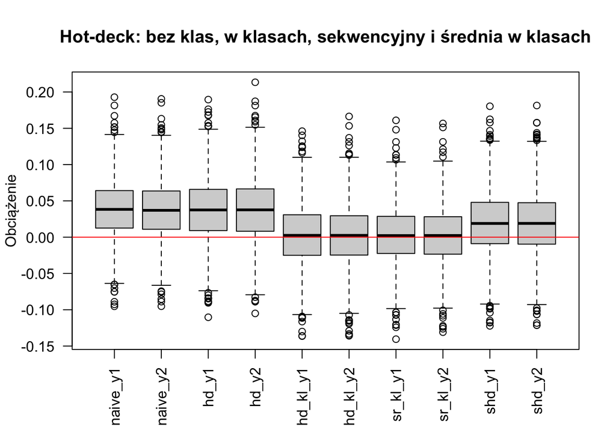

```r
# Ustawienie ziarna losowości dla reprodukowalności
set.seed(123)

# Parametry symulacji
N <- 50000  # rozmiar populacji
n <- 1000    # rozmiar próby

# Generowanie zmiennych objaśniających
x1 <- runif(N, 0, 1)
x2 <- runif(N, 0, 1)
e <- rnorm(N, 0, 1)

# Generowanie zmiennej y dla dwóch modeli
y1 <- -1 + x1 + x2 + e
y2 <- -1.167 + x1 + x2 + (x1-0.5)^2 + (x2-0.5)^2 + e

# Tworzenie wskaźnika odpowiedzi (mechanizm braków danych)
logit_p <- 0.2 + x1 + x2
p <- exp(logit_p)/(1 + exp(logit_p))

# Tworzenie ramki danych
populacja <- data.frame(
 id = 1:N,
 x1 = x1,
 x2 = x2,
 y1 = y1,
 y2 = y2,
 p = p,
 ## klasy imputacyjne
 klasa = interaction(cut(x1, breaks = seq(0, 1, 0.25)), cut(x2, breaks = seq(0, 1, 0.25)))
)
y_true <- colMeans(populacja[, c("y1", "y2")])

## imputacja średnią w klasach
impute_srednia <- function(proba, y) {
  srednie <- ave(proba[[y]], proba$klasa, FUN = function(v) mean(v, na.rm = TRUE))
  ifelse(is.na(proba[[y]]), srednie, proba[[y]])
}

## symulacja (2000 razy)
R <- 2000
results <- matrix(0, R, 10)
colnames(results) <- paste0(rep(c("naive", "hd", "hd_kl", "sr_kl", "shd"), each = 2),
                            rep(c("_y1", "_y2"), times = 5))

for (r in 1:R) {
  proba <- populacja[sample(1:N, n), ]
  proba$delta <- rbinom(nrow(proba), 1, proba$p)
  proba$y1[proba$delta == 0] <- NA
  proba$y2[proba$delta == 0] <- NA

  results[r, 1:2] <- colMeans(proba[, c("y1", "y2")], na.rm = TRUE)
  results[r, 3:4] <- colMeans(impute_rhd(proba, y1 + y2 ~ 1, pool = "univariate")[, c("y1", "y2")])
  results[r, 5:6] <- colMeans(impute_rhd(proba, y1 + y2 ~ klasa, pool = "univariate")[, c("y1", "y2")])
  results[r, 7:8] <- c(mean(impute_srednia(proba, "y1")), mean(impute_srednia(proba, "y2")))
  results[r, 9:10] <- colMeans(impute_shd(proba, y1 + y2 ~ x1, pool = "univariate")[, c("y1", "y2")])
}

boxplot(results - matrix(rep(y_true, times = 5), byrow = TRUE, ncol = 10, nrow = R),
        xlab = "", ylab = "Obciążenie",
        main = "Hot-deck: bez klas, w klasach, sekwencyjny i średnia w klasach",
        las = 2)
abline(a = 0, b = 0, col = "red")
```

Obciążenie estymatora (x100)

```r
bias <- colMeans(results) - rep(y_true, times = 5)
round(bias*100, 2)
```

```
naive_y1 naive_y2    hd_y1    hd_y2 hd_kl_y1 hd_kl_y2 sr_kl_y1 sr_kl_y2
    3.85     3.78     3.82     3.79     0.28     0.28     0.30     0.27
  shd_y1   shd_y2
    1.95     1.92
```

Wariancja (x100)

```r
round(apply(results, 2, var)*100, 4)
```

```
naive_y1 naive_y2    hd_y1    hd_y2 hd_kl_y1 hd_kl_y2 sr_kl_y1 sr_kl_y2
  0.1499   0.1518   0.1751   0.1861   0.1716   0.1684   0.1471   0.1477
  shd_y1   shd_y2
  0.1819   0.1838
```

RMSE (x100)

```r
round(sqrt(bias^2 + apply(results, 2, var))*100, 2)
```

```
naive_y1 naive_y2    hd_y1    hd_y2 hd_kl_y1 hd_kl_y2 sr_kl_y1 sr_kl_y2
    5.46     5.43     5.67     5.74     4.15     4.11     3.85     3.85
  shd_y1   shd_y2
    4.69     4.70
```

Średnia w klasach ma mniejszą wariancję estymatora średniej niż hot-deck, ale zaniża rozproszenie zmiennej. Hot-deck przepisuje wartości obserwowane, więc lepiej zachowuje rozkład, co widać na odchyleniu standardowym w jednej próbie.

```r
set.seed(2025)
proba <- populacja[sample(1:N, n), ]
y1_pelne <- proba$y1
proba$y1[rbinom(n, 1, proba$p) == 0] <- NA

round(c(prawda = sd(y1_pelne),
        respondenci = sd(proba$y1, na.rm = TRUE),
        hd_kl = sd(impute_rhd(proba, y1 ~ klasa)$y1),
        sr_kl = sd(impute_srednia(proba, "y1"))), 3)
```

```
     prawda respondenci       hd_kl       sr_kl
      1.111       1.102       1.109       0.982
```

**Python**

```python
# Ustawienie ziarna losowości
np.random.seed(123)

# Parametry symulacji
N = 50000  # rozmiar populacji
n = 1000    # rozmiar próby

# Generowanie zmiennych objaśniających
x1 = np.random.uniform(0, 1, N)
x2 = np.random.uniform(0, 1, N)
e = np.random.normal(0, 1, N)

# Generowanie zmiennej y dla dwóch modeli
y1 = -1 + x1 + x2 + e
y2 = -1.167 + x1 + x2 + (x1-0.5)**2 + (x2-0.5)**2 + e

# Tworzenie wskaźnika odpowiedzi
logit_p = 0.2 + x1 + x2
p = np.exp(logit_p)/(1 + np.exp(logit_p))

# Tworzenie ramki danych
populacja = pd.DataFrame({
   'id': range(N),
   'x1': x1,
   'x2': x2,
   'y1': y1,
   'y2': y2,
   'p': p,
   # klasy imputacyjne
   'klasa': np.minimum(x1 // 0.25, 3) * 4 + np.minimum(x2 // 0.25, 3)
})

y_true = populacja[['y1', 'y2']].mean()

# Imputacja średnią w klasach
def impute_srednia(proba, y):
    return proba[y].fillna(proba.groupby('klasa')[y].transform('mean'))

# Symulacja (2000 razy)
R = 2000
results = np.zeros((R, 10))
columns = [f"{t}_{y}" for t in ['naive', 'hd', 'hd_kl', 'sr_kl', 'shd'] for y in ['y1', 'y2']]

for r in range(R):
    # Losowanie próby
    proba = populacja.sample(n=n)

    # Generowanie braków danych
    delta = np.random.binomial(1, proba['p'])
    proba.loc[delta == 0, ['y1', 'y2']] = np.nan

    results[r, 0:2] = proba[['y1', 'y2']].mean()
    results[r, 2:4] = [hotdeck_losowy(proba, y).mean() for y in ['y1', 'y2']]
    results[r, 4:6] = [hotdeck_losowy(proba, y, klasy='klasa').mean() for y in ['y1', 'y2']]
    results[r, 6:8] = [impute_srednia(proba, y).mean() for y in ['y1', 'y2']]
    results[r, 8:10] = [hotdeck_sekwencyjny(proba, y, 'x1').mean() for y in ['y1', 'y2']]

plt.figure(figsize=(10, 6))
plt.boxplot(results - np.tile(y_true, 5))
```

[output not shown]

```python
plt.axhline(y=0, color='r', linestyle='-')
plt.xlabel('')
plt.ylabel('Obciążenie')
plt.title('Hot-deck: bez klas, w klasach, sekwencyjny i średnia w klasach')
plt.xticks(range(1, 11), columns, rotation=90)
```

[output not shown]

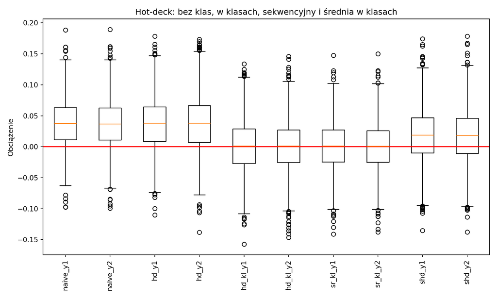

```python
plt.tight_layout()
plt.show()
```

Obciążenie estymatora (x100), wariancja (x100) i RMSE (x100)

```python
bias = results.mean(axis=0) - np.tile(y_true, 5)
pd.DataFrame({'bias': np.round(bias*100, 2),
              'var': np.round(results.var(axis=0, ddof=1)*100, 4),
              'rmse': np.round(np.sqrt(bias**2 + results.var(axis=0, ddof=1))*100, 2)},
             index=columns)
```

```
          bias     var  rmse
naive_y1  3.77  0.1512  5.42
naive_y2  3.72  0.1536  5.40
hd_y1     3.70  0.1767  5.60
hd_y2     3.74  0.1847  5.70
hd_kl_y1  0.08  0.1712  4.14
hd_kl_y2  0.12  0.1705  4.13
sr_kl_y1  0.12  0.1479  3.85
sr_kl_y2  0.10  0.1490  3.86
shd_y1    1.85  0.1871  4.70
shd_y2    1.83  0.1889  4.72
```

Średnia w klasach ma mniejszą wariancję estymatora średniej niż hot-deck, ale zaniża rozproszenie zmiennej. Hot-deck przepisuje wartości obserwowane, więc lepiej zachowuje rozkład, co widać na odchyleniu standardowym w jednej próbie.

```python
np.random.seed(2025)
proba = populacja.sample(n=n)
y1_pelne = proba['y1'].copy()
proba.loc[np.random.binomial(1, proba['p']) == 0, 'y1'] = np.nan

pd.Series({'prawda': y1_pelne.std(),
           'respondenci': proba['y1'].std(),
           'hd_kl': hotdeck_losowy(proba, 'y1', klasy='klasa').std(),
           'sr_kl': impute_srednia(proba, 'y1').std()}).round(3)
```

```
prawda         1.062
respondenci    1.059
hd_kl          1.047
sr_kl          0.926
dtype: float64
```

# 5 Ćwiczenie na zajęcia

1. Proszę wczytać zbiór `data4-czytelnictwo.csv`.
2. Proszę zaimputować `czyta_ksiazki_z_brakami` losowym hot-deckiem w klasach wyznaczonych przez inne zmienne niż w przykładzie 2.
3. Proszę powtórzyć imputację dla 100 różnych ziaren i sprawdzić, jak zmienia się oszacowana średnia. Co to mówi o niepewności pojedynczej imputacji?